# Practical Machine Learning - Prediction Assignment Writeup

Johanna Fajardo-Gonzalez

3/28/2020

## Background

Using devices such as Jawbone Up, Nike FuelBand, and Fitbit it is now possible to collect a large amount of data about personal activity relatively inexpensively. These type of devices are part of the quantified self movement – a group of enthusiasts who take measurements about themselves regularly to improve their health, to find patterns in their behavior, or because they are tech geeks. One thing that people regularly do is quantify how much of a particular activity they do, but they rarely quantify how well they do it. In this project, our goal will be to use data from accelerometers on the belt, forearm, arm, and dumbell of 6 participants. They were asked to perform barbell lifts correctly and incorrectly in 5 different ways.

More information is available from the website here: http://groupware.les.inf.puc-rio.br/har (see the section on the Weight Lifting Exercise Dataset).

## Data

The training data for this project are available here:

https://d396qusza40orc.cloudfront.net/predmachlearn/pml-training.csv

The test data are available here:

https://d396qusza40orc.cloudfront.net/predmachlearn/pml-testing.csv

The data for this project come from this source: http://groupware.les.inf.puc-rio.br/har.

## Objective of the Analysis

The goal of this project is to predict the manner in which the participants did the exercise. This is the `classe` variable in the training set. Other variables to predict with are also used.

## Examining the Data

### Loading the data

```r
#Set working directory
setwd("C:/Users/deisyf/Dropbox/PLM")
```

We start by loading the required R packages and setting a seed.

```r
#Load required packages
suppressMessages(library(lattice))
suppressMessages(library(ggplot2))
suppressMessages(library(caret))
suppressMessages(library(rpart))
suppressMessages(library(rpart.plot))
suppressMessages(library(corrplot))
suppressMessages(library(rattle))
suppressMessages(library(randomForest))
suppressMessages(library(RColorBrewer))
```

```r
#set seed
set.seed(1234)
```

```r
#Download data from the web
url_train <- "http://d396qusza40orc.cloudfront.net/predmachlearn/pml-training.csv"
url_test  <- "http://d396qusza40orc.cloudfront.net/predmachlearn/pml-testing.csv"
```

```r
#Creating training and test data
#data_train <- read.csv(url(url_train), strip.white = TRUE, na.strings = c("NA",""))
#data_test  <- read.csv(url(url_test),  strip.white = TRUE, na.strings = c("NA",""))
data_train <- read.csv("pml-training.csv", na.strings = c("NA", ""))
data_test  <- read.csv("pml-testing.csv", na.strings = c("NA", ""))
```

```r
#structure of datasets
dim(data_train)
```

```
## [1] 19622   160
```

```r
dim(data_test)
```

```
## [1]  20 160
```

The training dataset has 19,622 observations and 160 variables. The test (quiz) dataset contains 20 observations and 160 variables, the same as those in the training set.

### Cleaning the Data

The two datasets (`data_train` and `data_test`) have a large number of NA values, as well as near-zero-variance (NZV) variables. These will be removed for the purpose of the analysis.

We first remove the NA values.

```r
data_train  <- data_train [, colSums(is.na(data_train )) == 0]
data_test <- data_test[, colSums(is.na(data_test)) == 0]
```

```r
dim(data_train)
```

```
## [1] 19622    60
```

```r
dim(data_test)
```

```
## [1] 20 60
```

We now remove the NZV variables.

```r
nzv_var <- nearZeroVar(data_train)
data_train <- data_train[ , -nzv_var]
data_test  <- data_test[ , -nzv_var]
```

```r
dim(data_train)
```

```
## [1] 19622    59
```

```r
dim(data_test)
```

```
## [1] 20 59
```

The first five predictors are also removed since these variables are identifiers.

```r
data_train<- data_train[, -c(1:5)]
data_test <- data_test[, -c(1:5)]
```

```r
dim(data_train)
```

```
## [1] 19622    54
```

```r
dim(data_test)
```

```
## [1] 20 54
```

The number of variables for the analysis has been reduced from 160 to 54.

### Splitting the Data

We now create a cross validation dataset to compare the model created by the training subset. This is to compute the out-of-sample errors. Thus, we split the cleaned training set into a training set (train, 60%) for prediction and a validation set (valid, 40%).

```r
inTrain <- createDataPartition(data_train$classe, p = 0.6, list = FALSE)
train <- data_train[inTrain, ]
validation <- data_train[-inTrain, ]
```

## Building the Model

### Creating the Prediction Model

Here we create two models to predict the `classe` outcome: 1. Classification Tree; and 2. Random Forest.

In this analysis, we consider a 5-fold cross-validation (default setting in trainControl function is k=10).

```r
set.seed(1234)
control <- trainControl(method = "cv", number = 5)
```

#### Classification Tree

We now obtain the classification tree:

```r
set.seed(1234)
fit_decision_tree <- train(classe ~ ., data = train, method="rpart", trControl = control)
print(fit_decision_tree, digits = 4)
```

```
## CART
##
## 11776 samples
##    53 predictor
##     5 classes: 'A', 'B', 'C', 'D', 'E'
##
## No pre-processing
## Resampling: Cross-Validated (5 fold)
## Summary of sample sizes: 9422, 9421, 9420, 9420, 9421
## Resampling results across tuning parameters:
##
##   cp       Accuracy  Kappa
##   0.03809  0.5405    0.4128
##   0.06111  0.4173    0.2107
##   0.11652  0.3497    0.1000
##
## Accuracy was used to select the optimal model using the largest value.
## The final value used for the model was cp = 0.03809.
```

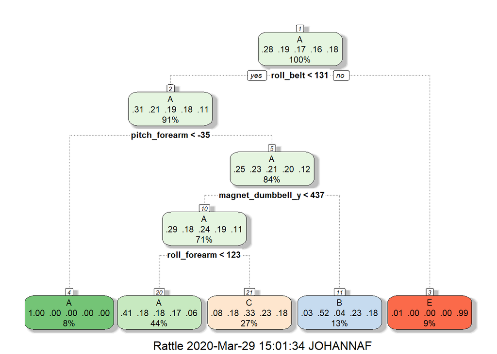

```r
fancyRpartPlot(fit_decision_tree$finalModel)
```

We now calculate the predictions of the decision tree model on the validation data.

```r
predict_decision_tree <- predict(fit_decision_tree, newdata = validation)
conf_matrix_decision_tree <- confusionMatrix(predict_decision_tree, validation$classe)
conf_matrix_decision_tree
```

```
## Confusion Matrix and Statistics
##
##           Reference
## Prediction    A    B    C    D    E
##          A 2029  638  644  567  209
##          B   44  505   49  232  211
##          C  155  375  675  487  383
##          D    0    0    0    0    0
##          E    4    0    0    0  639
##
## Overall Statistics
##
##                Accuracy : 0.4904
##                  95% CI : (0.4793, 0.5016)
##     No Information Rate : 0.2845
##     P-Value [Acc > NIR] : < 2.2e-16
##
##                   Kappa : 0.3339
##
##  Mcnemar's Test P-Value : NA
##
## Statistics by Class:
##
##                      Class: A Class: B Class: C Class: D Class: E
## Sensitivity            0.9091  0.33267  0.49342   0.0000  0.44313
## Specificity            0.6334  0.91530  0.78388   1.0000  0.99938
## Pos Pred Value         0.4965  0.48511  0.32530      NaN  0.99378
## Neg Pred Value         0.9460  0.85114  0.87992   0.8361  0.88852
## Prevalence             0.2845  0.19347  0.17436   0.1639  0.18379
## Detection Rate         0.2586  0.06436  0.08603   0.0000  0.08144
## Detection Prevalence   0.5209  0.13268  0.26447   0.0000  0.08195
## Balanced Accuracy      0.7712  0.62399  0.63865   0.5000  0.72125
```

```r
(accuracy_rpart <- conf_matrix_decision_tree$overall[1])
```

```
## Accuracy
## 0.490441
```

The predictive accuracy of the decision tree model is relatively low at 0.4904. The out-of-sample error is 0.5096.

#### Random Forest

We now use a random forest model to predict the `classe` outcome.

```r
set.seed(1234)
fit_random_forest <- train(classe ~ ., data = train, method = "rf",
                   trControl = control)
print(fit_random_forest, digits = 4)
```

```
## Random Forest
##
## 11776 samples
##    53 predictor
##     5 classes: 'A', 'B', 'C', 'D', 'E'
##
## No pre-processing
## Resampling: Cross-Validated (5 fold)
## Summary of sample sizes: 9422, 9421, 9420, 9420, 9421
## Resampling results across tuning parameters:
##
##   mtry  Accuracy  Kappa
##    2    0.9918    0.9896
##   27    0.9960    0.9950
##   53    0.9924    0.9904
##
## Accuracy was used to select the optimal model using the largest value.
## The final value used for the model was mtry = 27.
```

The following are the prediction outcomes on the validation data:

```r
# Predict outcomes using validation set
predict_random_forest <- predict(fit_random_forest, validation)
# Show prediction result
(conf_random_forest <- confusionMatrix(validation$classe, predict_random_forest))
```

```
## Confusion Matrix and Statistics
##
##           Reference
## Prediction    A    B    C    D    E
##          A 2232    0    0    0    0
##          B    4 1511    3    0    0
##          C    0    3 1364    1    0
##          D    0    0    6 1280    0
##          E    0    3    0    2 1437
##
## Overall Statistics
##
##                Accuracy : 0.9972
##                  95% CI : (0.9958, 0.9982)
##     No Information Rate : 0.285
##     P-Value [Acc > NIR] : < 2.2e-16
##
##                   Kappa : 0.9965
##
##  Mcnemar's Test P-Value : NA
##
## Statistics by Class:
##
##                      Class: A Class: B Class: C Class: D Class: E
## Sensitivity            0.9982   0.9960   0.9934   0.9977   1.0000
## Specificity            1.0000   0.9989   0.9994   0.9991   0.9992
## Pos Pred Value         1.0000   0.9954   0.9971   0.9953   0.9965
## Neg Pred Value         0.9993   0.9991   0.9986   0.9995   1.0000
## Prevalence             0.2850   0.1933   0.1750   0.1635   0.1832
## Detection Rate         0.2845   0.1926   0.1738   0.1631   0.1832
## Detection Prevalence   0.2845   0.1935   0.1744   0.1639   0.1838
## Balanced Accuracy      0.9991   0.9975   0.9964   0.9984   0.9996
```

```r
(accuracy_random_forest <- conf_random_forest$overall[1])
```

```
## Accuracy
## 0.997196
```

The accuracy rate is 0.9972 and the out-of-sample error rate is 0.0028.

## Applying the Prediction Model

The random forest model, which uses the `classe` variable in the training set and has the highest accuracy, is applied to 20 test cases available in the quiz data (`data_test`).

```r
predict_quiz <- (predict(fit_random_forest, data_test))
predict_quiz
```

```
##  [1] B A B A A E D B A A B C B A E E A B B B
## Levels: A B C D E
```

## Concluding Remarks

To summarize, the predictive accuracy of the two models evaluated is as follows:

– Decision Tree Model: 49.04%

– Random Forest Model: 99.72%

The random forest model with cross-validation produces the most accurate model for these data.